# Load neccesary libraries and the data

# RQ4: What types of target activities (TARGETID) are most frequently interacted with by students who complete the course?"

### Filter students who completed the course by selecting rows where LABEL == 0.

### Count interactions per TARGETID using .value_counts().

### Extract the top 10 most interacted TARGETIDs using .head(10).

### Plot the results using Matplotlib to visualize which activities are most popular.

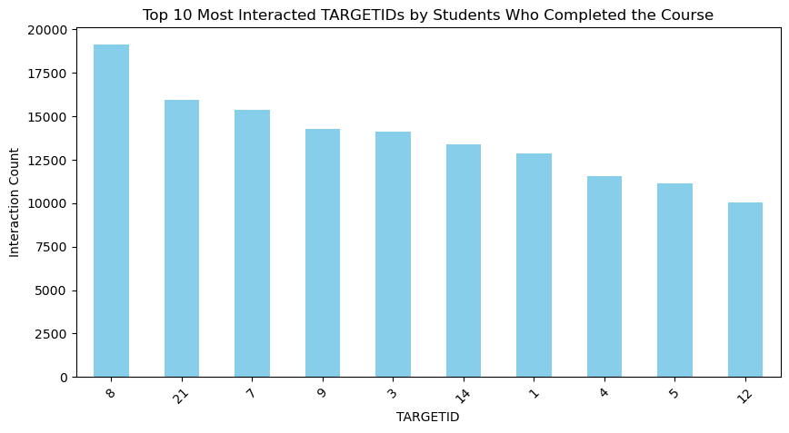

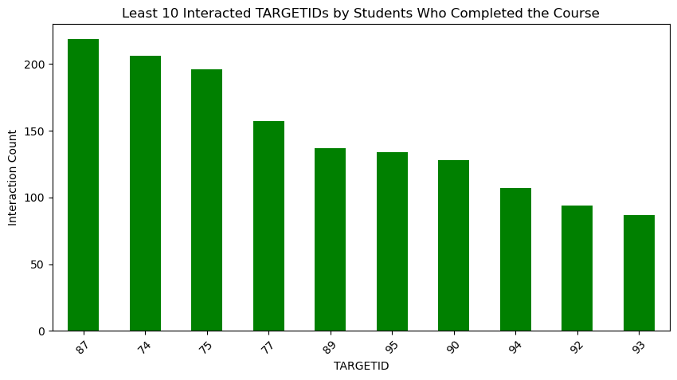

```python
# Load dataset
df = pd.read_csv(file_path)

# Step 1: Filter students who completed the course (LABEL == 0)
completed_students = df[df['LABEL'] == 0]

# Step 2: Count interactions per TARGETID
target_counts = completed_students['TARGETID'].value_counts()

# Step 3: Get the top 10 most interacted TARGETIDs
top_targets = target_counts.head(10)

# Step 4: Visualize results
plt.figure(figsize=(10,5))
top_targets.plot(kind='bar', color='skyblue')
plt.xlabel('TARGETID')
plt.ylabel('Interaction Count')
plt.title('Top 10 Most Interacted TARGETIDs by Students Who Completed the Course')
plt.xticks(rotation=45)
plt.show()


# Step 4: Get the top 10 least interacted TARGETIDs
least_targets = target_counts.tail(10)

# Step 6: Visualize results
plt.figure(figsize=(10,5))
least_targets.plot(kind='bar', color='green')
plt.xlabel('TARGETID')
plt.ylabel('Interaction Count')
plt.title('Least 10 Interacted TARGETIDs by Students Who Completed the Course')
plt.xticks(rotation=45)
plt.show()
```

# RQ5: Do more student exhibit consistent engagement over time or does a greater number show intermittent or late engagement?

```python
import seaborn as sns
import matplotlib.patches as mpatches
from scipy.stats import chi2_contingency

# Load dataset
df = pd.read_csv(file_path)

# Convert timestamp to a meaningful time unit (e.g., weeks)
df['Week'] = df['TIMESTAMP'] // (7 * 24 * 60 * 60)  # Convert seconds to weeks

# Count number of actions per user per week
user_activity = df.groupby(['USERID', 'Week']).size().reset_index(name='ActionCount')

# Compute engagement consistency (mean and standard deviation of activity per user)
engagement_stats = user_activity.groupby('USERID')['ActionCount'].agg(['mean', 'std']).reset_index()
engagement_stats.fillna(0, inplace=True)  # Replace NaN with 0 for inactive users

# Ensure at least two unique bin edges for qcut
if engagement_stats['std'].nunique() > 2:
    num_bins = min(4, engagement_stats['std'].nunique())  # Ensure valid bins
    bin_labels = ['Consistent', 'Moderate', 'Intermittent', 'Late'][:num_bins - 1]  # Labels must be one fewer than bins
    engagement_stats['Engagement_Type'] = pd.qcut(engagement_stats['std'], q=num_bins, labels=bin_labels, duplicates='drop')
else:
    engagement_stats['Engagement_Type'] = 'Consistent'  # Default if all std values are the same

# Merge engagement stats with original dataset to include labels (dropout status)
df = df.merge(engagement_stats[['USERID', 'Engagement_Type']], on='USERID', how='left')

# Compute retention rates for each engagement type
retention_rates = df.groupby('Engagement_Type')['LABEL'].mean()

# Count number of users in each engagement category
user_counts = engagement_stats['Engagement_Type'].value_counts()
per_counts = (user_counts/ sum(user_counts))*100
print("Percentage counts per engagement type:")
print(per_counts)
```

```
Percentage counts per engagement type:
Engagement_Type
Consistent      50.007095
Moderate        25.372499
Intermittent    24.620406
Name: count, dtype: float64
```